# Unit 2 (Ch. 3 - 5)

ECON 2106

Dr. Josh Martin

## The Paradox of Value

- Which is more valuable: **diamonds** or **water**?
  - Diamonds have greater **exchange value**
  - Water has greater **use value**
- Why does something essential (water) cost so little, while something non-essential (diamonds) costs so much?

## Utility

- **Utility**: the satisfaction or benefit a person receives from consumption
- Utility is:
  - **Subjective**
  - **Context-dependent**
  - **Not directly observable**
- Economists do note measure utility directly; we infer it from choices

## Revealed Preferences

- **Revealed preferences**: choices reveal the ordering of preferences
  - If $A \succ B$ and $B \succ C$, then $A \succ C$
- **Willingness to pay** provides a practical way to approximate utility

## Marginal Utility

- **Marginal utility**: the additional satisfaction from one more unit of a good
- **Law of diminishing marginal utility**: As consumption increases, marginal utility decreases
- Utility increases with consumption, but at a **decreasing rate**
- Because water is abundant, its **marginal utility** is low
- Because diamonds are scarce, their **marginal utility** is high

## Marginal Utility

[video not shown]

## Demand

- If:
  - Utility $\approx$ willingness to pay, and
  - Marginal utility falls with each additional unit consumed,
- Then:
  - **Price and quantity demanded are negatively related**
  - This is the **Law of Demand**

## Why Does the Law of Demand Hold?

Three reinforcing forces:

- **1. Diminishing Marginal Utility**
  - Each additional unit provides less additional satisfaction
- **2. Income Effect**
  - When price rises, purchasing power falls
  - Like a pay cut: you can afford less overall
- **3. Substitution Effect**
  - When a good becomes relatively more expensive, people shift toward alternatives
  - Example: if the price of coffee rises, some consumers switch to tea

## The Consumer Decision Rule

Individuals continue consuming until:

$$\text{Marginal Utility} = \text{Price}$$

- If **price falls**:
  - $MU > P$
  - Consume **more** until equality is restored
- If **price rises**:
  - $MU < P$
  - Consume **less** until equality is restored

## Demand

[figure not shown]

## Demand

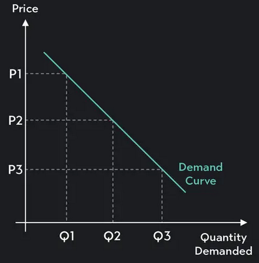

## Determinants of Demand

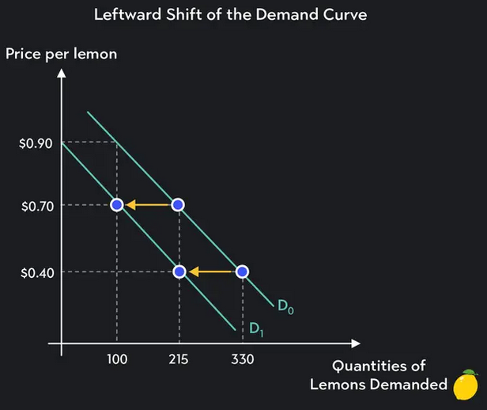

## Determinants of Demand

A change in any of the following shifts the **entire demand curve**:

- **Tastes and Preferences**
  - If Crocs become more popular → demand increases
  - If they fall out of fashion → demand decreases
- **Number of Buyers**
  - Larger population → greater demand
  - Increase in the legal drinking age → fewer buyers → lower demand for alcohol

## Determinants of Demand

A change in any of the following shifts the **entire demand curve**:

- **Income**
  - **Normal goods**: demand rises as income rises
  - **Inferior goods**: demand falls as income rises
- **Prices of Related Goods**
  - **Complements**: price of $Y$ ↑ → demand for $X$ ↓
  - **Substitutes**: price of $Y$ ↑ → demand for $X$ ↑

## Determinants of Demand: Research Example

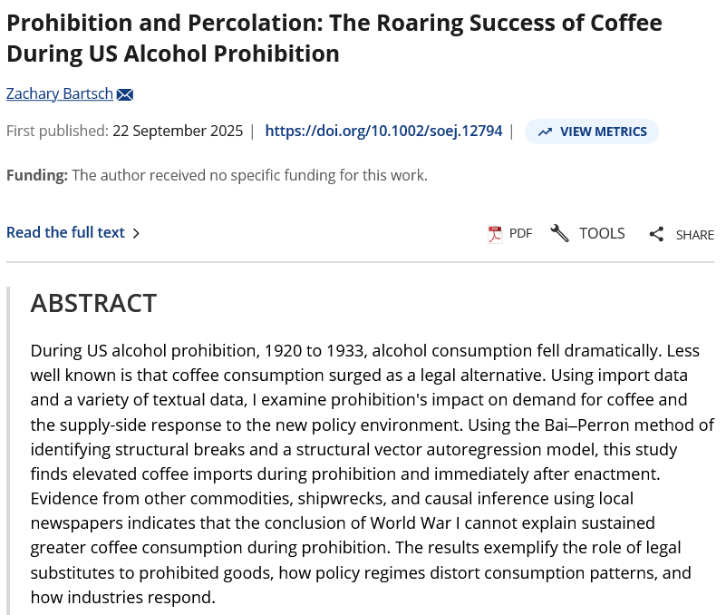

Bartsch (2026)

## Determinants of Demand

A change in any of the following shifts the **entire demand curve**:

- **Expectations**
  - Expect higher future prices → greater demand today
  - Expect lower future prices → lower demand today

## Determinants of Demand: Research Example

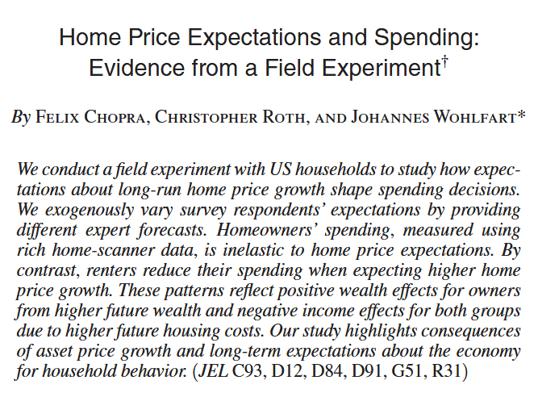

Chopra, Roth, and Wohlfart (2025)

## Demand vs. Quantity Demanded

- **Demand**: the entire relationship between price and quantity

  $$Q(P) = a - bP$$
- **Quantity demanded**: the specific quantity at a given price

  $$Q(P_1) = a - bP_1$$
- A **change in price** causes:
  - A movement **along** the demand curve
  - NOT a shift of the curve

## Demand vs. Quantity demanded

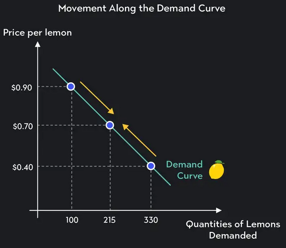

## Demand vs. Quantity demanded

[figure not shown]

## Elasticity of Demand

- **Price Elasticity of Demand**: measures how responsive quantity demanded is to a change in price
- Visually:
  - **Elastic demand** → relatively flat curve
  - **Inelastic demand** → relatively steep curve
- Interpretation:
  - Elastic: a small change in price → large change in quantity
  - Inelastic: a large change in price → small change in quantity

## Elasticity of Demand

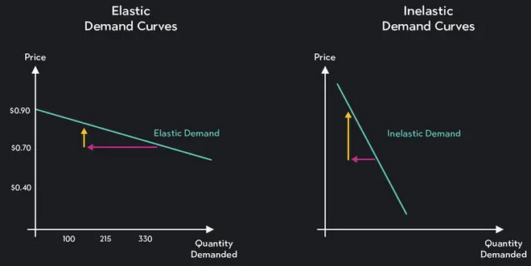

## What Affects Demand Elasticity?

- Elasticity tends to be greater when:
  - There are **close substitutes**
  - Consumers have **weak brand attachment**
  - The good is a **luxury** rather than a necessity
  - Consumers have **more time** to adjust
- Elasticity tends to be smaller when:
  - There are **few substitutes**
  - The good is a **necessity**
  - The good represents a **small share of income**

## Elasticity of Demand: Research Example

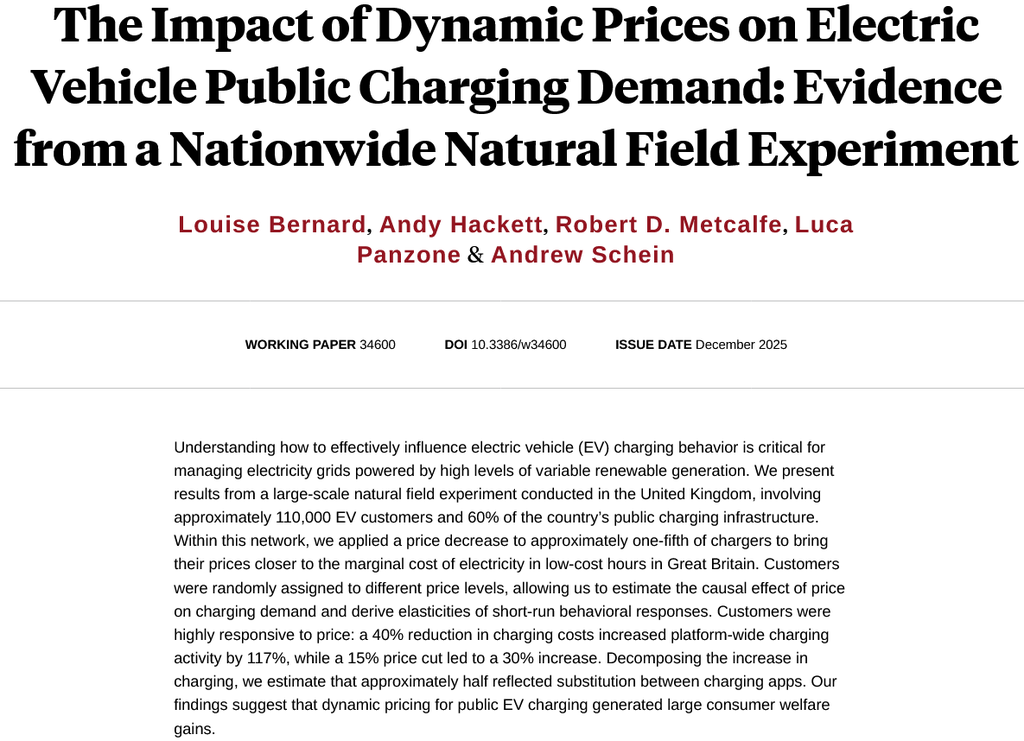

Bernard et al. (2025)

## Supply

- **Supply** reflects the minimum amount sellers are willing to accept to provide different quantities of a good or service
  - The supply curve represents all quantities sellers are willing to sell at each possible price
- The Law of Supply: There is a **positive relationship** between price and quantity supplied
  - A **change in price** causes a movement along the supply curve
  - A **change in supply** shifts the entire curve

## Supply

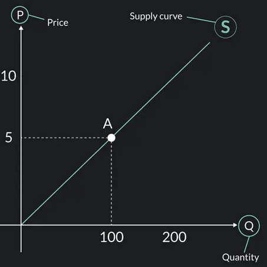

## Why do Supply curves slope upwards?

[figure not shown]

## Supply vs. Quantity supplied

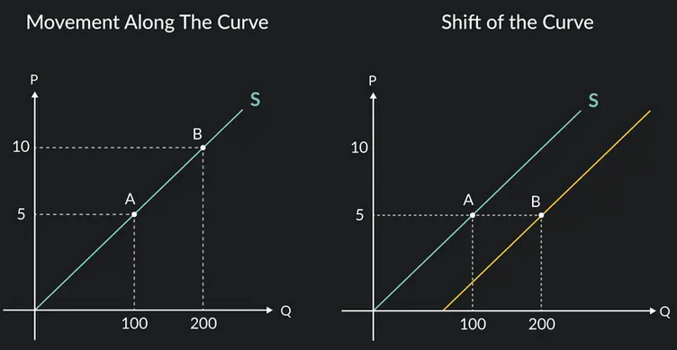

## Determinants of Supply

A change in any of the following shifts the **entire supply curve**:

- **Cost of Inputs**
  - Increase in wages → supply decreases
  - Decrease in raw material costs → supply increases
- **Productivity (Technology)**
  - Improved production technology → supply increases
  - Better worker training → supply increases

## Determinants of Supply

A change in any of the following shifts the **entire supply curve**:

- **Number of Producers**
  - Entry of new firms → supply increases
  - Firms exiting the market → supply decreases
- **Expectations**
  - Expect higher future prices → supply today decreases
  - Expect lower future prices → supply today increases

## Elasticity of Supply

- **Price Elasticity of Supply**: Measures how responsive quantity supplied is to a change in price
- Visually:
  - **Elastic supply** → relatively flat curve
  - **Inelastic supply** → relatively steep curve
- Interpretation:
  - Elastic: a small change in price → large change in quantity supplied
  - Inelastic: a large change in price → small change in quantity supplied

## What Affects Supply Elasticity?

The primary determinant is **time**.

- **Short run**:
  - Supply is more inelastic
  - Firms cannot easily adjust capital or capacity
- **Long run**:
  - Supply is more elastic
  - Firms can enter, exit, expand, or adopt new technology
- Other factors:
  - Availability of inputs
  - Flexibility of production processes

## Equilibrium

- The Supply & Demand model is a **partial equilibrium (PE)** model
- It focuses on one market at a time
  - Captures the primary effects within that market
  - Does not track all ripple effects across the entire economy

## Equilibrium

- Analogy:
  - Like observing the first wave from a stone thrown into a pond
  - PE models focus on the immediate impact
- A key assumption: **ceteris paribus**
  - “All else equal”
  - We hold other factors constant while analyzing one change

## Market Equilibrium

- The interaction of supply and demand determines market price
- The **equilibrium price** is the price at which:

$$Q_D = Q_S$$

- At this price (denoted as $p^*$):
  - Quantity demanded equals quantity supplied
  - There is no pressure for price to change

## Market Equilibrium

It is called “equilibrium” because competitive forces eliminate imbalances

- If price is **too high**: $Q_D < Q_S$ (surplus)
  - Sellers compete for customers
  - Price is pushed **down**
- If price is **too low**: $Q_D > Q_S$ (shortage)
  - Buyers compete for goods
  - Price is pushed **up**

## Equilibrium

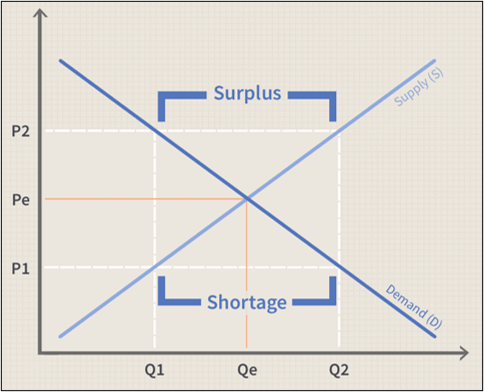

## Demand Increases

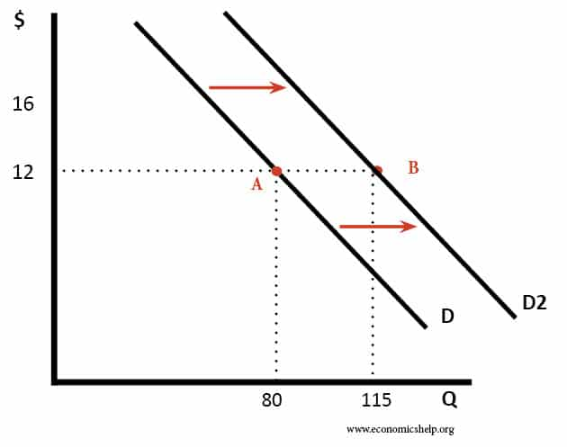

## Demand Increases

- Consider the market for eggs at Easter:
  - $\uparrow D_e$
  - $\uparrow P_e$ and $\uparrow Q_e$
- The higher price serves two key allocation purposes:
  - Encourages consumers to **conserve** (reduce quantity demanded)
  - Encourages producers to **expand output**
    - Prices coordinate behavior without central direction

## Demand Decreases

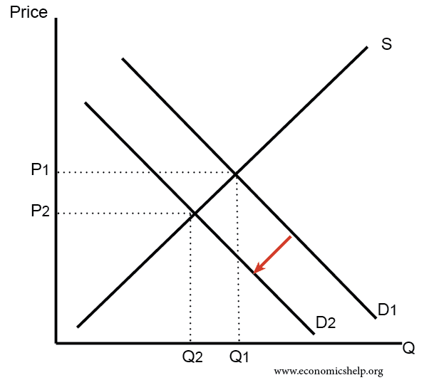

## Demand Decreases

- Consider the market for the Apple Macintosh Portable:
  - $\downarrow D_{pc}$
  - $\downarrow P_{pc}$ and $\downarrow Q_{pc}$
- The lower price serves important allocation purposes:
  - Signals producers that the product is less desired
  - Frees scarce resources (labor, capital, materials) for more valued uses

## Creative Destruction & Economic Dynamis

- **Creative destruction** is a process in which new innovations replace and make obsolete older innovations
  - The economy grows not because nothing changes, but because it is constantly reallocating resources to more productive uses
- In a typical year in the U.S.:
  - ~13 million jobs are destroyed
  - ~16 million jobs are created (Chamberlain 2016)

## Creative Destruction & Economic Dynamism

- Modern growth theory was developed by **Philippe Aghion** and **Peter Howitt** (winners of the 2025 Nobel Prize in Economics)
  - “How can an economy grow steadily if millions of jobs are destroyed each year?”
- Because growth is driven by dynamism, not stability.
  - Firms innovate to “escape competition”
  - New entrants replace less productive incumbents
  - Competition creates continuous improvement
- Economic growth can appear stable at the macro level  
  even though it is turbulent at the micro level.

## Supply Decreases

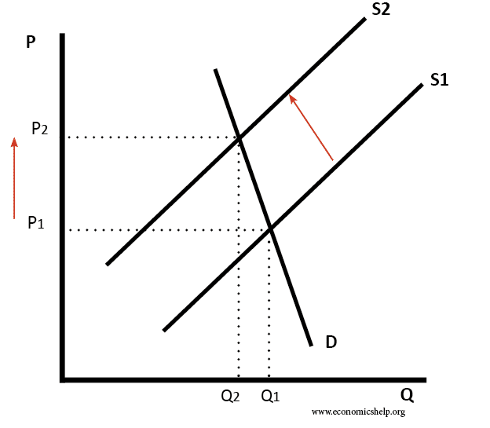

## Supply Decreases

- Consider the market for avocados after a drought:
  - $\downarrow S_a$
  - $\uparrow P_a$ and $\downarrow Q_a$
- The higher price:
  - Encourages consumers to conserve
  - Encourages producers to increase production where possible
  - Rations the now-scarcer good without central direction

## Supply Increases

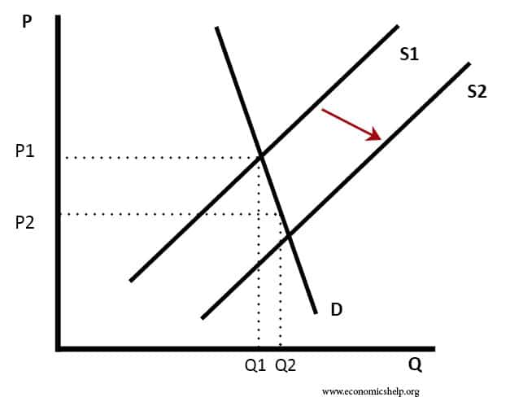

## Supply Increases

- Suppose zoning laws are relaxed, making it easier to build homes:
  - $\uparrow S_h$
  - $\downarrow P_h$ and $\uparrow Q_h$
- The lower price:
  - Makes housing more affordable
  - Expands access
  - Encourages greater market activity

## Supply Increases: A Common Misconception

- “Housing is more expensive where there are more homes. Therefore, building more homes makes housing more expensive.”
  - This confuses **correlation** with **causation**.
- Expensive cities have high demand.
  - Increasing supply puts **downward pressure** on prices.

## Supply Increases: A Common Misconception

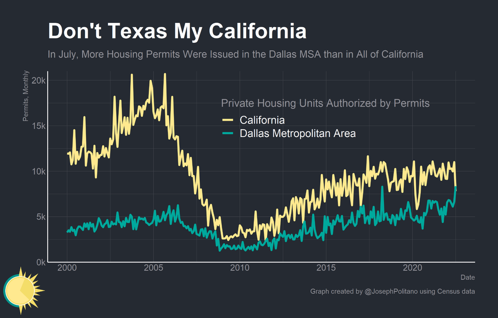

## Supply Increases: A Common Misconception

[video not shown]

## Jevons Paradox

- **Jevons Paradox**: When technological improvements make a good or service cheaper or more efficient, total usage can increase — not decrease.
- Efficiency ↓ cost of use
  - Lower cost → higher quantity demanded
  - If demand expands enough, total usage rises
- Originally observed in coal:
  - More efficient steam engines
  - Lower effective cost of coal
  - Total coal consumption increased

## Jevons Paradox

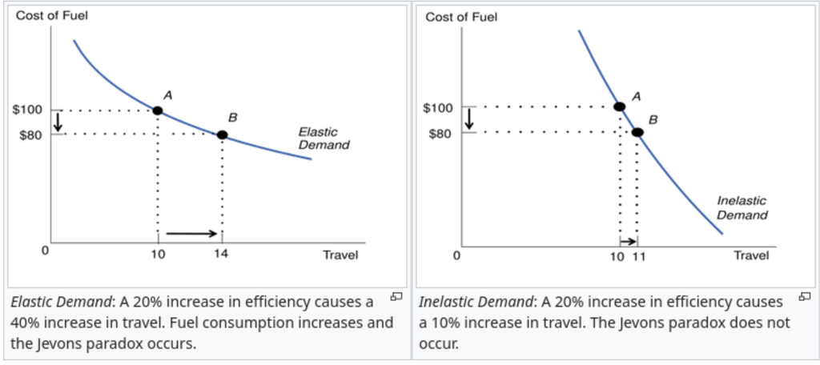

## Jevons Paradox

- Example: ATMs and bank tellers
  - ATMs reduced routine transaction costs
  - Branches became cheaper to operate
  - Banks opened more branches
  - Tellers shifted toward customer service & advisory roles
- Why didn’t teller employment immediately fall?
  - Lower cost → expanded demand for banking services
  - Automation substituted for *some* tasks
  - But complemented higher-skill tasks

## Induced Demand

- When expanding supply lowers the cost of use, quantity demanded increases — often offsetting the intended benefit.
- Transportation example:
  - Expanding highways ↓ travel time
  - Lower travel time = lower “price” of driving
  - More people choose to drive
- Empirical evidence: Goodwin (1996)
  - Short run elasticity ≈ −0.5
  - Long run elasticity ≈ −1.0
    - A 1% decrease in travel time → 1% increase in traffic in the long run

## Induced Demand: Why This Happens

- Adding road capacity shifts supply right:
  - ↓ travel time
  - ↓ effective cost of driving
  - ↑ quantity demanded
- Over time:
  - People move farther from work
  - More discretionary trips occur
  - Development patterns adjust
- Result: Congestion returns.

## Induced Demand: Research Example

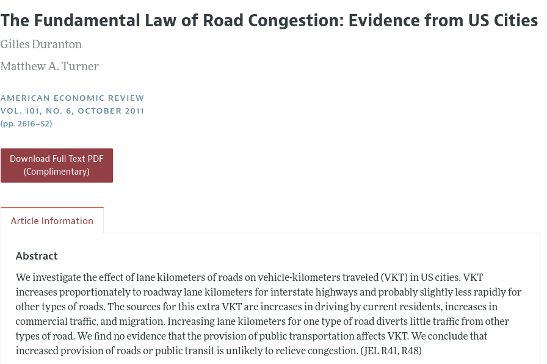

Duranton and Turner (2011)

## PE Predictions: Single Shift

|  | P | Q |
| --- | --- | --- |
| S $\uparrow$ |  |  |
| S $\downarrow$ |  |  |
| D $\uparrow$ |  |  |
| D $\downarrow$ |  |  |

|  | P | Q |
| --- | --- | --- |
| S $\uparrow$ | $\downarrow$ | $\uparrow$ |
| S $\downarrow$ | $\uparrow$ | $\downarrow$ |
| D $\uparrow$ | $\uparrow$ | $\uparrow$ |
| D $\downarrow$ | $\downarrow$ | $\downarrow$ |

## PE Predictions: Double Shifts

[interactive chart not shown]

## PE Predictions: Double Shifts

|  | P | Q |
| --- | --- | --- |
| S $\uparrow$; D $\uparrow$ |  |  |
| S $\uparrow$; D $\downarrow$ |  |  |
| S $\downarrow$; D $\uparrow$ |  |  |
| S $\downarrow$; D $\downarrow$ |  |  |

|  | P | Q |
| --- | --- | --- |
| S $\uparrow$; D $\uparrow$ | ¯\_(ツ)_/¯ | $\uparrow$ |
| S $\uparrow$; D $\downarrow$ | $\downarrow$ | ¯\_(ツ)_/¯ |
| S $\downarrow$; D $\uparrow$ | $\uparrow$ | ¯\_(ツ)_/¯ |
| S $\downarrow$; D $\downarrow$ | ¯\_(ツ)_/¯ | $\downarrow$ |

## Double Shifts: Research Example

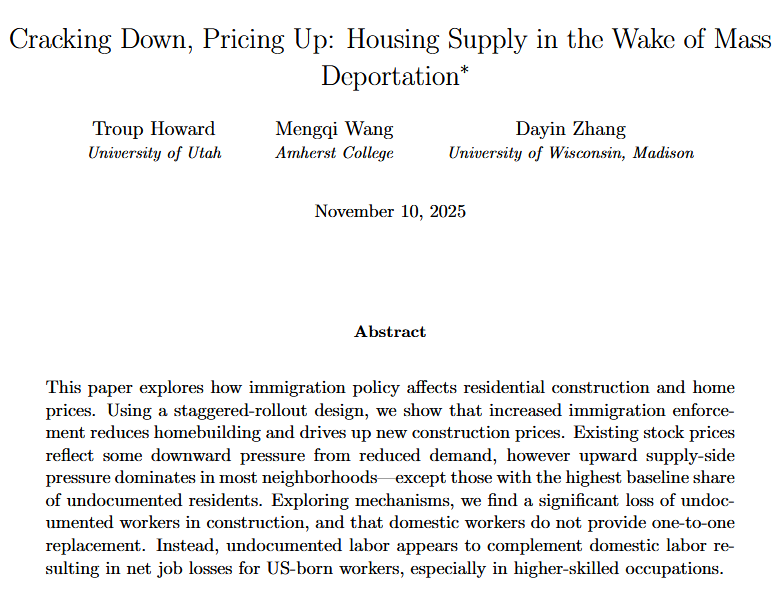

## The Role of Prices in Allocation

- Prices emerge from the voluntary interactions of buyers and sellers
- They allocate scarce resources:
  - Toward those who value them most
  - Toward producers who can supply them most efficiently
- No central authority decides:
  - How guacamole prices should adjust
  - Which firms process the remaining avocado supply
  - Which cities receive shipments
  - Which consumers ultimately recieve them

## Prices as Information

- Efficient allocation requires a way to **compare the value** of alternative uses of resources
  - Most inputs can produce multiple outputs and most outputs can be produced using different inputs
  - Prices provide a common measure of value
- Without prices:
  - Allocation becomes arbitrary
  - Or dependent on subjective judgment
  - Or reliant on incomplete information

## Markets as a Dynamic Process

- Markets are constantly evolving
  - A drought in one region can shift production elsewhere
  - A change in input costs can alter supply chains
  - Adjustment occurs fluidly — without central direction
- Each participant holds only a small piece of knowledge
  - Individuals act in their own interest
  - Not to serve society
  - But to exchange labor and skills for income
- **Markets coordinate this dispersed knowledge**

## The Invisible Hand

[video not shown]

## Central Planning vs. Decentralized Markets

- After WWII, economists debated centralized vs. decentralized planning.
  - F.A. Hayek opposed the idea of a Central Pricing Board
- His key insight:
  - Knowledge is **dispersed**
  - No central authority can gather or process all relevant information

## Central Planning vs. Decentralized Markets

- Market prices:
  - Continuously incorporate local knowledge
  - Adjust dynamically
  - Reflect changing conditions
- Decentralized systems align with the dispersed nature of information.

## Hayek

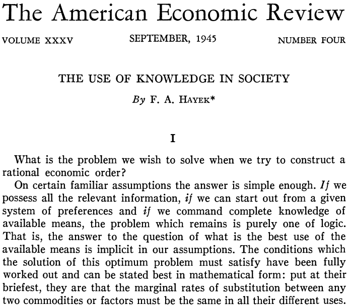

Hayek (1945)

## An Excellent Hayekian Meme

[figure not shown]

## Disequilibrium

- So far, we have focused on the allocative benefits of **free markets**.
- A **free market** is an economic system in which prices are determined by voluntary exchange between buyers and sellers, without external restrictions.
- In reality, many markets operate under **artificial price restrictions**, such as:
  - Minimum wage laws
  - “Price gouging” laws
  - Rent control
  - Zoning regulations

## Price Floors and Price Ceilings

- Governments sometimes regulate prices by making certain transactions illegal.
  - When binding, these policies prevent the market from reaching equilibrium.
- **Price floor:** a legal minimum price.
  - Example: minimum wage.
- **Price ceiling:** a legal maximum price.
  - Example: rent control.

## Price Floors and Ceilings

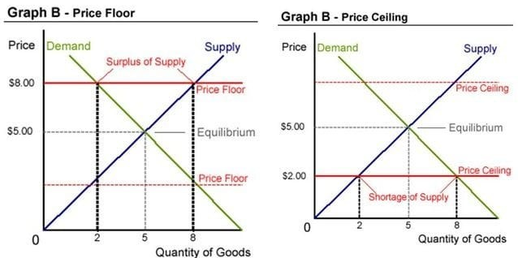

## Disequilibrium: Impacts of Price Controls

- Price controls generate both **direct** and **indirect** effects.
  - The overall impact depends on whether the price control is **binding**.
- Direct Effects
  - **Shortages** (with binding price ceilings)
  - **Surpluses** (with binding price floors)
- Indirect Effects
  - Changes in **quality**
  - Longer **wait times**
  - **Substitution** toward alternative goods
  - Emergence of **black markets**

## Example: Direct Effects of Disequilibrium

[figure not shown]

Lordan and Neumark (2018)

## Example: Direct Effects of Disequilibrium

[figure not shown]

## Example: Direct Effects of Disequilibrium

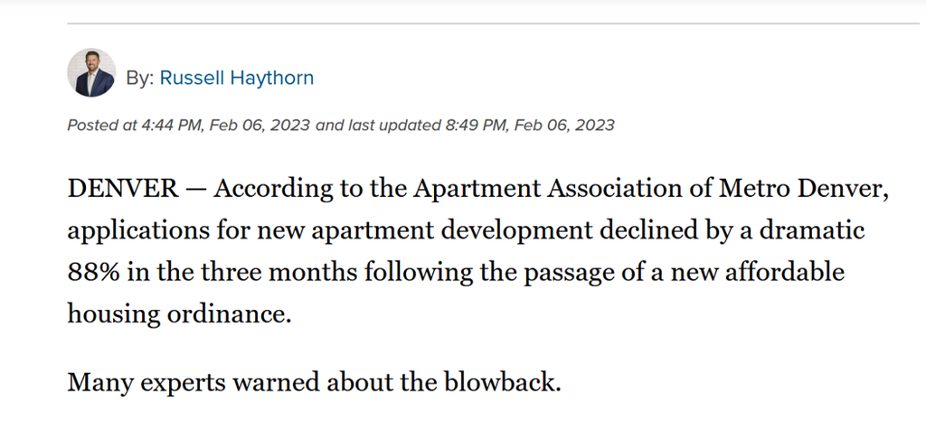

## Example: Direct Effects of Disequilibrium

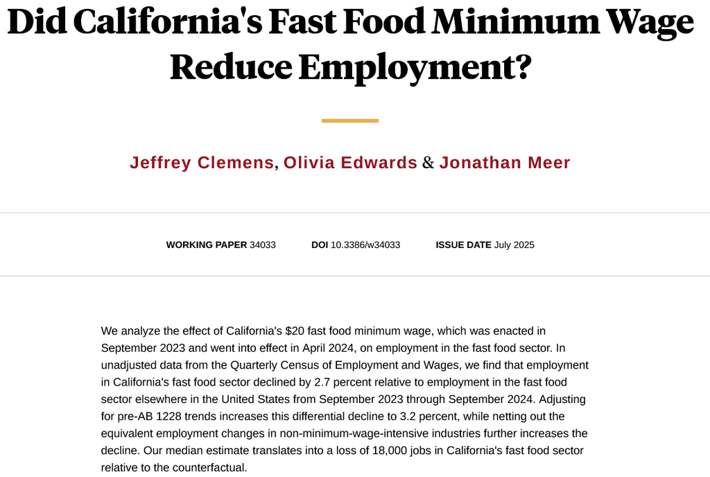

Clemens, Edwards, and Meer (2025)

## Example: Direct Effects of Disequilibrium

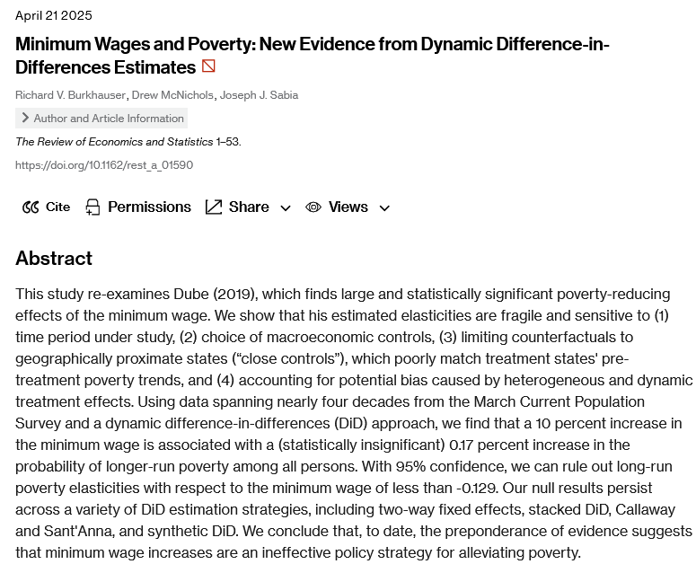

Burkhauser, McNichols, and Sabia (2025)

## Example: Direct Effects of Disequilibrium

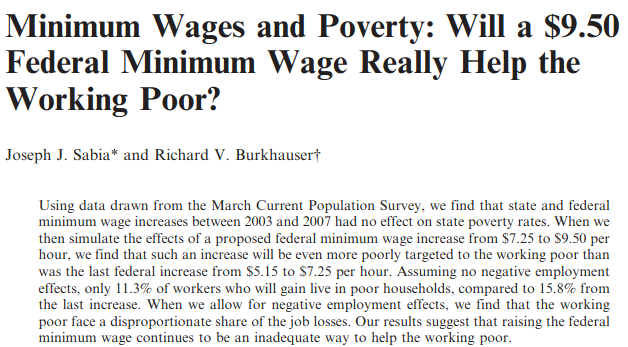

Sabia and Burkhauser (2010)

## Where will MW be most binding?

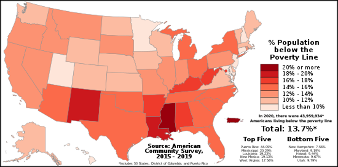

## Surplus (Welfare) and DWL

- **Consumer Surplus** = the difference between what consumers are willing to pay and what they actually pay.
- **Producer Surplus** = the difference between what producers receive and their minimum acceptable price.
- When price controls are binding:
  - Fewer goods are bought and sold.
  - Mutually beneficial trades are lost.
  - This lost welfare is known as **deadweight loss (DWL)**.

## Surplus (Welfare) and DWL

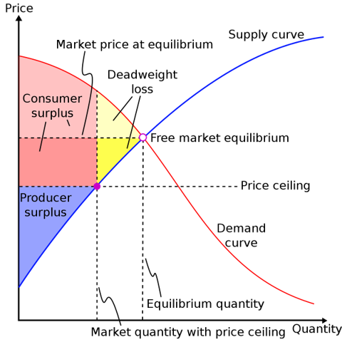